```
## tibble [8 × 3] (S3: tbl_df/tbl/data.frame)
##  $ Trimestre            : Factor w/ 8 levels "I Trimestre 2022",..: 1 2 3 4 5 6 7 8
##  $ Tasa desempleo       : num [1:8] 13.6 11.7 12 11.7 10.6 ...
##  $ Población desempleada: num [1:8] 330227 284800 296971 287085 248779 ...
```

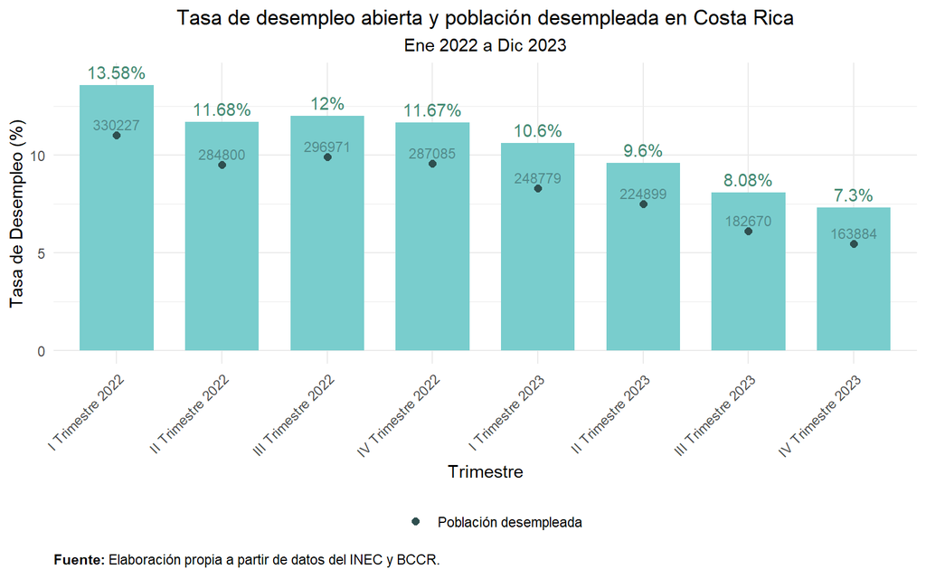

Durante el transcurso del año 2022 en Costa Rica, se observó una tendencia descendente en los índices de desempleo a excepción del III Trimestre, acompañada de una disminución en la participación activa en el mercado laboral. De acuerdo con datos proporcionados por el Instituto Nacional de Estadística y Censos (INEC), este período inició con una tasa de desempleo del 13,58%, que descendió gradualmente hasta alcanzar un 11,67% al cierre del año. Aunque el Gobierno ha atribuido esta disminución en la fuerza laboral principalmente a la jubilación, es fundamental considerar otros posibles factores que pudieron influir en esta tendencia.

El desempleo en Costa Rica cerró el año 2023 con una tasa del 7,3%, lo que representó una notable disminución de 4,4 puntos porcentuales en comparación con el año anterior, donde se registraba en un 11,67%. Siendo esta la menor tasa de desempleo en 13 años. En términos absolutos, el 7,3% de desempleo equivale a aproximadamente 164.000 personas. La disminución en la participación laboral se refleja en una notable caída de 5,9 puntos porcentuales en la tasa de participación.

El informe del INEC también destaca cambios significativos en la distribución de la ocupación por sectores económicos. Se observó una reducción en la construcción, actividades profesionales y administrativas de apoyo, así como en hogares como empleadores. Por otro lado, se registraron aumentos en sectores como la enseñanza, la salud y la administración pública. Estos cambios en la estructura ocupacional pueden tener implicaciones importantes para la economía y el mercado laboral en general.

```
## 'data.frame':    22 obs. of  4 variables:
##  $ Trimestre         : Factor w/ 22 levels "ENE(22)-MAR(22)",..: 1 2 3 4 5 6 7 8 9 10 ...
##  $ Tasa_desempleo    : num  13.6 13.3 12 11.7 11.8 11.8 12 11.4 11.6 11.7 ...
##  $ Tasa_participacion: num  59.6 60 59.9 59.6 60.1 60.2 60.5 60.3 60 59.7 ...
##  $ Tasa_ocupacion    : num  51.5 52 52.8 52.6 53 53.1 53.3 53.4 53.1 52.8 ...
```

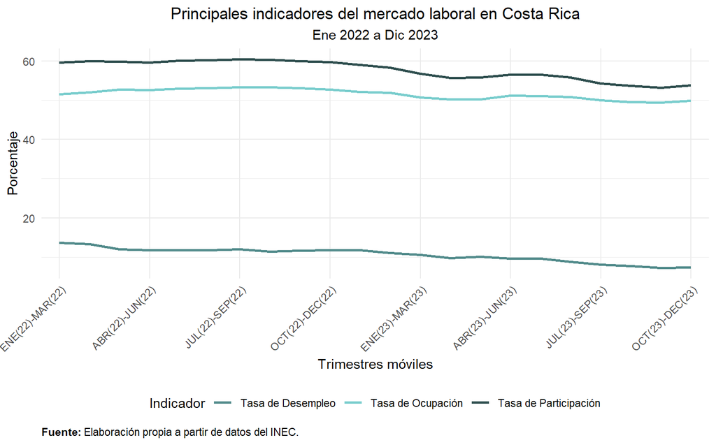